# 04 - Scaling relationships and variation

04_scaling_and_variation.qmd

# Overview

This document outlines the investigation of the allometric relationships between threat devices and body size in the male trimorphic *Longiperna concolor*.

# Load data

The `MALES` dataset—generated in `01_exploratory_analysis.qmd` and further refined in `02_morph_discrimination.qmd`—contains individual-level information (ID, sex, and morphological measurements) for all *L. concolor* males included in this study. It also provides both the original morph classifications proposed by Zatz et al. (2011) and the updated classifications obtained here using our trimodal bivariate mixture model, applying 80%, 85%, 90%, and 95% probability thresholds for morph assignment.

```
'data.frame':   631 obs. of  8 variables:
 $ ID       : Factor w/ 631 levels "100M","101M",..: 109 218 321 417 494 555 588 620 631 11 ...
 $ DSmm     : num  6.1 5.44 6.03 6.02 5.61 5.71 5.59 6 5.76 5.98 ...
 $ F4mm     : num  57 31.5 55.3 57.5 35.7 ...
 $ MorphZatz: Factor w/ 2 levels "Major","Minor": 1 1 1 1 1 1 1 1 1 1 ...
 $ T80      : Factor w/ 4 levels "NI","Alpha","Beta",..: 2 3 2 2 3 1 2 2 2 2 ...
 $ T85      : Factor w/ 4 levels "NI","Alpha","Beta",..: 2 3 2 2 3 1 2 2 2 2 ...
 $ T90      : Factor w/ 4 levels "NI","Alpha","Beta",..: 2 3 2 2 3 1 2 2 2 2 ...
 $ T95      : Factor w/ 4 levels "NI","Alpha","Beta",..: 2 1 2 2 3 1 2 2 2 2 ...
```

# Scaling relationships

Below, we assess whether varying the probability thresholds affects the allometric relationships estimated with the ordinary least squares method. Across all male morphs, the overall pattern remains consistent, although the absolute values change. Alphas remain hypoallometric, betas hyperallometric, and gammas isometric across all threshold values.

### Alpha allometry

```
    Intercept Int_2.5 Int_97.5 Slope Slope_2.5 Slope_97.5       Pattern
T80      1.40    1.20     1.60  0.43      0.17       0.68 Hypoallometry
T85      1.41    1.22     1.60  0.42      0.17       0.67 Hypoallometry
T90      1.37    1.18     1.55  0.48      0.23       0.72 Hypoallometry
T95      1.36    1.19     1.52  0.50      0.29       0.72 Hypoallometry
```

### Beta allometry

```
    Intercept Int_2.5 Int_97.5 Slope Slope_2.5 Slope_97.5        Pattern
T80      0.10   -0.14     0.35  1.99      1.66       2.33 Hyperallometry
T85      0.15   -0.09     0.40  1.92      1.59       2.25 Hyperallometry
T90      0.33    0.09     0.58  1.68      1.34       2.01 Hyperallometry
T95      0.53    0.29     0.77  1.41      1.08       1.74 Hyperallometry
```

### Gamma allometry

```
    Intercept Int_2.5 Int_97.5 Slope Slope_2.5 Slope_97.5  Pattern
T80      0.74    0.32     1.16  0.81      0.22       1.40 Isometry
T85      0.58    0.15     1.01  1.02      0.43       1.62 Isometry
T90      0.49    0.04     0.94  1.14      0.51       1.76 Isometry
T95      0.20   -0.29     0.69  1.51      0.83       2.19 Isometry
```

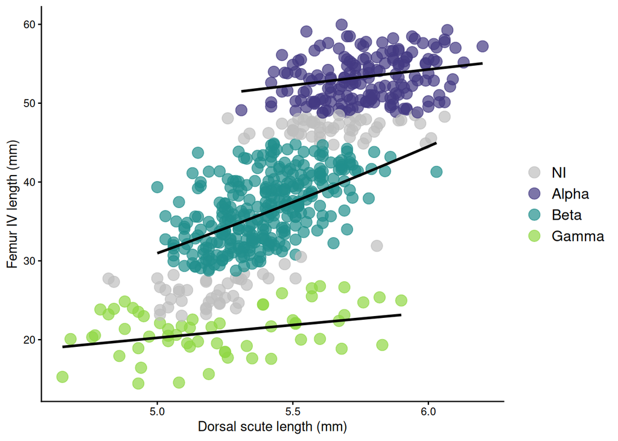

Figure 1: Allometric relationship between femur IV length and dorsal scute length (body size), with male morphs assigned using a bivariate mixture model. Gray points represent individuals with less than 80% confidence in morph assignment; these were excluded from the regression analyses. Black lines show ordinary least squares regressions fitted on log10-transformed variables and back-transformed to the original scale.

## Model diagnostics

We evaluated model diagnostics using the 80% threshold for morph determination.

### Alpha

For alpha males, the model is statistically valid, and the relationship between leg IV and body size is significant and hypoallometric (slope = 0.43, CI = 0.17-0.69, p = 0.001). However, dorsal scute length explains only a small fraction of the variation in leg IV length (R² = 0.05), indicating low predictive power of body size for leg size.

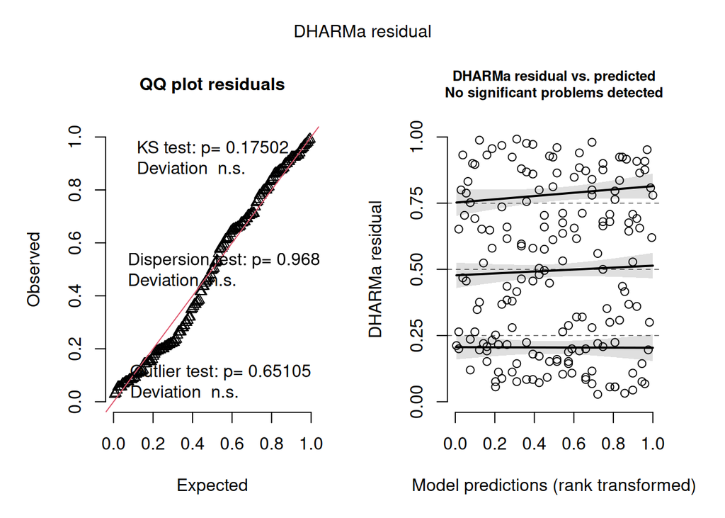

```
Call:
lm(formula = log10(F4mm) ~ log10(DSmm), data = MOR[MOR$Morph ==
    morphs[j], ])

Residuals:
      Min        1Q    Median        3Q       Max
-0.042066 -0.018700 -0.001807  0.017072  0.056038

Coefficients:
            Estimate Std. Error t value Pr(>|t|)
(Intercept)   1.3995     0.1000   13.99  < 2e-16 ***
log10(DSmm)   0.4273     0.1315    3.25  0.00139 **
---
Signif. codes:  0 '***' 0.001 '**' 0.01 '*' 0.05 '.' 0.1 ' ' 1

Residual standard error: 0.02264 on 170 degrees of freedom
Multiple R-squared:  0.05848,   Adjusted R-squared:  0.05294
F-statistic: 10.56 on 1 and 170 DF,  p-value: 0.001393
```

```
                2.5 %    97.5 %
(Intercept) 1.2020224 1.5969856
log10(DSmm) 0.1677196 0.6868453
```

### Beta

For beta males, the relationship between leg IV and body size is significant and clearly hyperallometric (slope = 1.99, 95% CI = 1.66–2.33, p < 2e-16), with a substantial fraction of variance in leg IV explained by body size (R² = 0.31). Model diagnostics indicate a slight deviation in the lower quantile of the residual distribution, suggesting mild heterogeneity at low F4mm values. As the other diagnostics are satisfactory, this deviation is unlikely to compromise model interpretation.

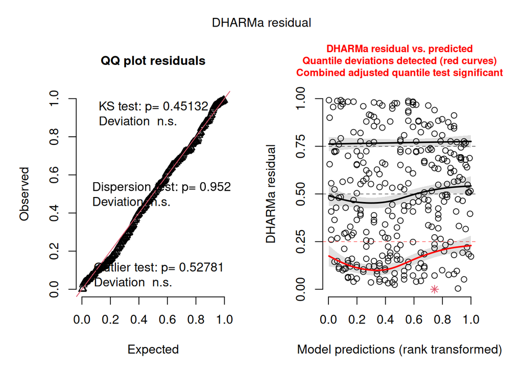

```
Call:
lm(formula = log10(F4mm) ~ log10(DSmm), data = MOR[MOR$Morph ==
    morphs[j], ])

Residuals:
      Min        1Q    Median        3Q       Max
-0.091772 -0.035582 -0.000694  0.026611  0.120618

Coefficients:
            Estimate Std. Error t value Pr(>|t|)
(Intercept)   0.1013     0.1253   0.808     0.42
log10(DSmm)   1.9931     0.1712  11.641   <2e-16 ***
---
Signif. codes:  0 '***' 0.001 '**' 0.01 '*' 0.05 '.' 0.1 ' ' 1

Residual standard error: 0.04288 on 305 degrees of freedom
Multiple R-squared:  0.3076,    Adjusted R-squared:  0.3053
F-statistic: 135.5 on 1 and 305 DF,  p-value: < 2.2e-16
```

```
                 2.5 %    97.5 %
(Intercept) -0.1453371 0.3478846
log10(DSmm)  1.6561642 2.3299966
```

### Gamma

For gamma males, the relationship between body size and leg IV length is positive and significant, but the slope does not differ from isometry (slope = 0.81, 95% CI = 0.21–1.41, p = 0.009). Similar to alphas, only a small fraction of the variation in leg length is explained by body size (R² = 0.1).

*Note: A warning appeared during residual simulation (`Fitting terminated with step failure`), but all other DHARMa diagnostics (uniformity, dispersion, outliers) indicate that model assumptions are met, suggesting that the warning reflects a minor numerical issue rather than a problem with the fit.*

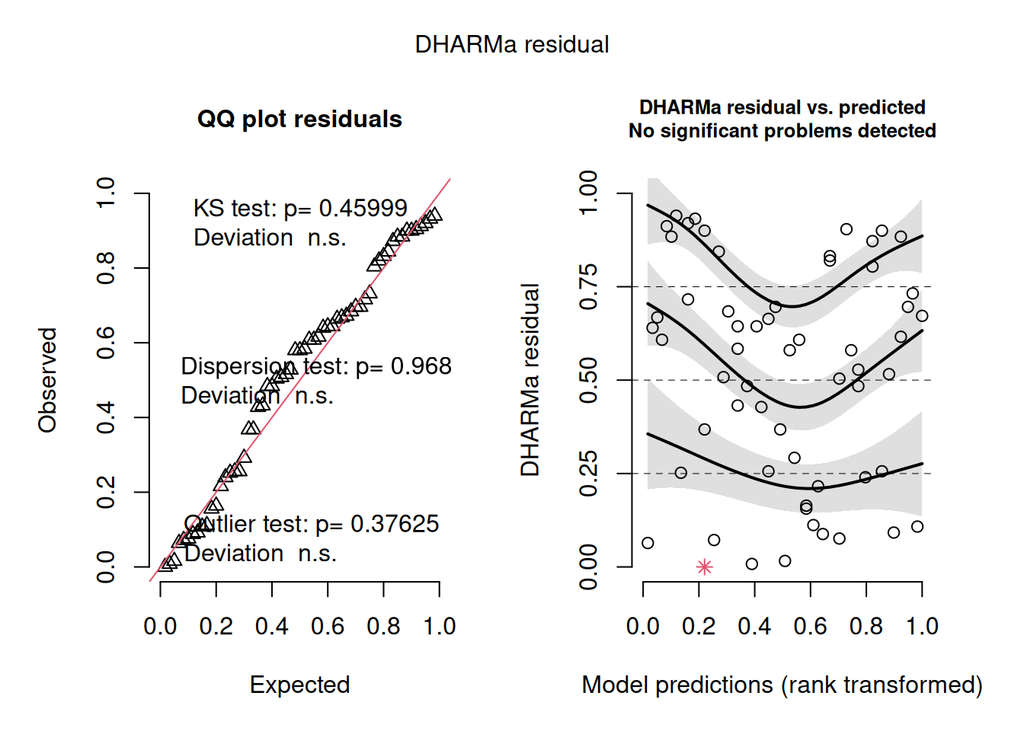

```
Call:
lm(formula = log10(F4mm) ~ log10(DSmm), data = MOR[MOR$Morph ==
    morphs[j], ])

Residuals:
     Min       1Q   Median       3Q      Max
-0.14925 -0.04212  0.01131  0.04073  0.09684

Coefficients:
            Estimate Std. Error t value Pr(>|t|)
(Intercept)   0.7418     0.2150   3.450  0.00106 **
log10(DSmm)   0.8084     0.2996   2.698  0.00915 **
---
Signif. codes:  0 '***' 0.001 '**' 0.01 '*' 0.05 '.' 0.1 ' ' 1

Residual standard error: 0.06137 on 57 degrees of freedom
Multiple R-squared:  0.1133,    Adjusted R-squared:  0.09772
F-statistic: 7.282 on 1 and 57 DF,  p-value: 0.009149
```

```
                2.5 %   97.5 %
(Intercept) 0.3112589 1.172381
log10(DSmm) 0.2084963 1.408219
```

# Assessment of normality of morphological traits

We assessed the normality of femur IV length and dorsal scute length for each male morph using the Shapiro-Wilk test.

Femur IV length deviated from normality in alpha and beta males (p < 0.001), whereas gamma males did not show evidence of departure from normality (p = 0.574). Dorsal scute length was approximately normal for all morphs (p > 0.05).

### Femur IV

#### Alpha

```
    Shapiro-Wilk normality test

data:  MALES$F4mm[MALES$T80 == "Alpha"]
W = 0.95628, p-value = 3.4e-05
```

#### Beta

```
    Shapiro-Wilk normality test

data:  MALES$F4mm[MALES$T80 == "Beta"]
W = 0.96531, p-value = 1.026e-06
```

#### Gamma

```
    Shapiro-Wilk normality test

data:  MALES$F4mm[MALES$T80 == "Gamma"]
W = 0.9829, p-value = 0.5738
```

### Dorsal scute length

#### Alpha

```
    Shapiro-Wilk normality test

data:  MALES$DSmm[MALES$T80 == "Alpha"]
W = 0.99241, p-value = 0.5054
```

#### Beta

```
    Shapiro-Wilk normality test

data:  MALES$DSmm[MALES$T80 == "Beta"]
W = 0.99155, p-value = 0.07657
```

#### Gamma

```
    Shapiro-Wilk normality test

data:  MALES$DSmm[MALES$T80 == "Gamma"]
W = 0.96675, p-value = 0.1065
```

# Bootstrap resampling to estimate variability

Because femur IV length was not normally distributed in all groups, we avoided relying on z-scores for standardization and instead quantified within-morph size variability using bootstrap resampling with the `boot` package (Angelo Canty and B. D. Ripley 2024).

For each morph, we used the adjusted bootstrap percentile method to estimate 95% confidence intervals for the standard deviation of both femur IV and dorsal scute lengths.

## Femur IV

### Alpha

#### Mean femur IV length (bootstrap)

```
ORDINARY NONPARAMETRIC BOOTSTRAP


Call:
boot(data = MOR$F4mm, statistic = mean_stat, R = 10000)


Bootstrap Statistics :
    original      bias    std. error
t1* 53.10849 -0.00321836    0.217202
```

##### 95% CI (mean)

```
BOOTSTRAP CONFIDENCE INTERVAL CALCULATIONS
Based on 10000 bootstrap replicates

CALL :
boot.ci(boot.out = mean_f4_boot[[i]], type = c("perc", "bca"))

Intervals :
Level     Percentile            BCa
95%   (52.68, 53.53 )   (52.70, 53.54 )
Calculations and Intervals on Original Scale
```

#### Standard deviation of femur IV length (bootstrap)

```
ORDINARY NONPARAMETRIC BOOTSTRAP


Call:
boot(data = MOR$F4mm, statistic = sd_stat, R = 10000)


Bootstrap Statistics :
    original      bias    std. error
t1* 2.861716 -0.01206451   0.1118958
```

##### 95% CI (sd)

```
BOOTSTRAP CONFIDENCE INTERVAL CALCULATIONS
Based on 10000 bootstrap replicates

CALL :
boot.ci(boot.out = sd_f4_boot[[i]], type = c("perc", "bca"))

Intervals :
Level     Percentile            BCa
95%   ( 2.630,  3.067 )   ( 2.662,  3.105 )
Calculations and Intervals on Original Scale
```

### Beta

#### Mean femur IV length (bootstrap)

```
ORDINARY NONPARAMETRIC BOOTSTRAP


Call:
boot(data = MOR$F4mm, statistic = mean_stat, R = 10000)


Bootstrap Statistics :
    original        bias    std. error
t1*  36.5499 -6.703583e-05   0.2414817
```

##### 95% CI (mean)

```
BOOTSTRAP CONFIDENCE INTERVAL CALCULATIONS
Based on 10000 bootstrap replicates

CALL :
boot.ci(boot.out = mean_f4_boot[[i]], type = c("perc", "bca"))

Intervals :
Level     Percentile            BCa
95%   (36.08, 37.03 )   (36.08, 37.03 )
Calculations and Intervals on Original Scale
```

#### Standard deviation of femur IV length (bootstrap)

```
ORDINARY NONPARAMETRIC BOOTSTRAP


Call:
boot(data = MOR$F4mm, statistic = sd_stat, R = 10000)


Bootstrap Statistics :
    original       bias    std. error
t1* 4.308755 -0.009815093   0.1179978
```

##### 95% CI (sd)

```
BOOTSTRAP CONFIDENCE INTERVAL CALCULATIONS
Based on 10000 bootstrap replicates

CALL :
boot.ci(boot.out = sd_f4_boot[[i]], type = c("perc", "bca"))

Intervals :
Level     Percentile            BCa
95%   ( 4.068,  4.528 )   ( 4.089,  4.555 )
Calculations and Intervals on Original Scale
```

### Gamma

#### Mean femur IV length (bootstrap)

```
ORDINARY NONPARAMETRIC BOOTSTRAP


Call:
boot(data = MOR$F4mm, statistic = mean_stat, R = 10000)


Bootstrap Statistics :
    original      bias    std. error
t1* 21.19492 0.002562661   0.3934659
```

##### 95% CI (mean)

```
BOOTSTRAP CONFIDENCE INTERVAL CALCULATIONS
Based on 10000 bootstrap replicates

CALL :
boot.ci(boot.out = mean_f4_boot[[i]], type = c("perc", "bca"))

Intervals :
Level     Percentile            BCa
95%   (20.41, 21.96 )   (20.39, 21.94 )
Calculations and Intervals on Original Scale
```

#### Standard deviation of femur IV length (bootstrap)

```
ORDINARY NONPARAMETRIC BOOTSTRAP


Call:
boot(data = MOR$F4mm, statistic = sd_stat, R = 10000)


Bootstrap Statistics :
    original     bias    std. error
t1*   3.0414 -0.0363618   0.2455217
```

##### 95% CI (sd)

```
BOOTSTRAP CONFIDENCE INTERVAL CALCULATIONS
Based on 10000 bootstrap replicates

CALL :
boot.ci(boot.out = sd_f4_boot[[i]], type = c("perc", "bca"))

Intervals :
Level     Percentile            BCa
95%   ( 2.522,  3.481 )   ( 2.615,  3.580 )
Calculations and Intervals on Original Scale
```

## Dorsal scute

### Alpha

#### Mean dorsal scute length (bootstrap)

```
ORDINARY NONPARAMETRIC BOOTSTRAP


Call:
boot(data = MOR$DSmm, statistic = mean_stat, R = 10000)


Bootstrap Statistics :
    original       bias    std. error
t1* 5.766453 -0.000175186  0.01339397
```

##### 95% CI (mean)

```
BOOTSTRAP CONFIDENCE INTERVAL CALCULATIONS
Based on 10000 bootstrap replicates

CALL :
boot.ci(boot.out = mean_ds_boot[[i]], type = c("perc", "bca"))

Intervals :
Level     Percentile            BCa
95%   ( 5.740,  5.793 )   ( 5.740,  5.793 )
Calculations and Intervals on Original Scale
```

#### Standard deviation of dorsal scute length (bootstrap)

```
ORDINARY NONPARAMETRIC BOOTSTRAP


Call:
boot(data = MOR$DSmm, statistic = sd_stat, R = 10000)


Bootstrap Statistics :
     original       bias    std. error
t1* 0.1745962 -0.000649449 0.007878582
```

##### 95% CI (sd)

```
BOOTSTRAP CONFIDENCE INTERVAL CALCULATIONS
Based on 10000 bootstrap replicates

CALL :
boot.ci(boot.out = sd_ds_boot[[i]], type = c("perc", "bca"))

Intervals :
Level     Percentile            BCa
95%   ( 0.1585,  0.1892 )   ( 0.1603,  0.1913 )
Calculations and Intervals on Original Scale
```

### Beta

#### Mean dorsal scute length (bootstrap)

```
ORDINARY NONPARAMETRIC BOOTSTRAP


Call:
boot(data = MOR$DSmm, statistic = mean_stat, R = 10000)


Bootstrap Statistics :
    original       bias    std. error
t1* 5.395863 8.614332e-05  0.01031594
```

##### 95% CI (mean)

```
BOOTSTRAP CONFIDENCE INTERVAL CALCULATIONS
Based on 10000 bootstrap replicates

CALL :
boot.ci(boot.out = mean_ds_boot[[i]], type = c("perc", "bca"))

Intervals :
Level     Percentile            BCa
95%   ( 5.376,  5.417 )   ( 5.376,  5.417 )
Calculations and Intervals on Original Scale
```

#### Standard deviation of dorsal scute length (bootstrap)

```
ORDINARY NONPARAMETRIC BOOTSTRAP


Call:
boot(data = MOR$DSmm, statistic = sd_stat, R = 10000)


Bootstrap Statistics :
     original        bias    std. error
t1* 0.1783993 -0.0004689827 0.006870763
```

##### 95% CI (sd)

```
BOOTSTRAP CONFIDENCE INTERVAL CALCULATIONS
Based on 10000 bootstrap replicates

CALL :
boot.ci(boot.out = sd_ds_boot[[i]], type = c("perc", "bca"))

Intervals :
Level     Percentile            BCa
95%   ( 0.1646,  0.1919 )   ( 0.1662,  0.1935 )
Calculations and Intervals on Original Scale
```

### Gamma

#### Mean dorsal scute length (bootstrap)

```
ORDINARY NONPARAMETRIC BOOTSTRAP


Call:
boot(data = MOR$DSmm, statistic = mean_stat, R = 10000)


Bootstrap Statistics :
    original        bias    std. error
t1* 5.225085 -0.0002890847  0.04189059
```

##### 95% CI (mean)

```
BOOTSTRAP CONFIDENCE INTERVAL CALCULATIONS
Based on 10000 bootstrap replicates

CALL :
boot.ci(boot.out = mean_ds_boot[[i]], type = c("perc", "bca"))

Intervals :
Level     Percentile            BCa
95%   ( 5.144,  5.308 )   ( 5.146,  5.310 )
Calculations and Intervals on Original Scale
```

#### Standard deviation of dorsal scute length (bootstrap)

```
ORDINARY NONPARAMETRIC BOOTSTRAP


Call:
boot(data = MOR$DSmm, statistic = sd_stat, R = 10000)


Bootstrap Statistics :
     original       bias    std. error
t1* 0.3252181 -0.003465318  0.02196546
```

##### 95% CI (sd)

```
BOOTSTRAP CONFIDENCE INTERVAL CALCULATIONS
Based on 10000 bootstrap replicates

CALL :
boot.ci(boot.out = sd_ds_boot[[i]], type = c("perc", "bca"))

Intervals :
Level     Percentile            BCa
95%   ( 0.2780,  0.3640 )   ( 0.2867,  0.3723 )
Calculations and Intervals on Original Scale
```

# Pairwise differences

To assess whether variability differed among morphs, we calculated all pairwise differences between the bootstrap distributions of standard deviations and derived 95% confidence intervals for these differences. Differences were considered significant if their intervals did not include zero.

## Femur IV length (bootstrap 95% CIs)

```
$`Alpha vs Beta`
     2.5%     97.5%
-1.770757 -1.132764

$`Alpha vs Gamma`
      2.5%      97.5%
-0.6774704  0.3823755

$`Beta vs Gamma`
     2.5%     97.5%
0.7683598 1.8309038
```

## Dorsal scute length (bootstrap 95% CIs)

```
$`Alpha vs Beta`
       2.5%       97.5%
-0.02442480  0.01614366

$`Alpha vs Gamma`
      2.5%      97.5%
-0.1931454 -0.1017389

$`Beta vs Gamma`
       2.5%       97.5%
-0.18857498 -0.09814502
```

## References

Angelo Canty, and B. D. Ripley. 2024. *Boot: Bootstrap r (s-Plus) Functions*.

Zatz, Camila, Rachel Werneck, Rogelio Macías-Ordóñez, and G. Machado. 2011. “Alternative Mating Tactics in Dimorphic Males of the Harvestman Longiperna Concolor (Arachnida: Opiliones).” *Behavioral Ecology and Sociobiology* 65 (May): 995–1005. https://doi.org/10.1007/s00265-010-1103-0.